# L1c3nc3 to C0d3

Cari Gostic, Furqan Khan, Keanna Knebel

2019/12/30 (updated: 2020-01-25)

**Warning: Some of the character sequences references in this report contain profanity and lewd language. Please be advised.**

# Introduction

For a small fee, drivers in the United States can request a specific sequence of two to eight alaphanumeric characters for their registered license plates. These vanity plates have been a source of humor and pride since their introduction in 1965. (“Licence Plates: A Timeline” 2015) A driver can apply for a vanity plate by submitting an applicaiton to their state’s Department of Motor Vehicles (DMV), and each state’s DMV has a unique submission process. For a vanity plate to be accepted by the New York State Department of Motor Vehicles (NYSDMV), the submitted sequence must (1) not be registered to any other car in New York and (2) be deemed “appropriate”. (“Learn About Personalized Plates” 2019) The NYSDMV has intial screening process of an application against a “[red-guide](https://github.com/datanews/license-plates/blob/master/red-guide.csv)”, which is a set of character sequences that are off-limits. (“Datanews/Licence-Plates” 2014) This includes sequences that are overtly profain, sequences that are reserved for special vehicle classes, and other vaguely defined restrictions. If a submission contains any sequence in the red guide, it is automatically rejected. Submissions that pass this initial screening are then reviewed by clerical staff. According to the regulations set out in New York State’s cancellation procedure (“Restrictions on Personalized Plates” 2018):

- A plate must have at least 1 letter
- A plate cannot consist of 6 numbers followed by a single letter
- A plate may not be “obscene, lavacious, derogatory to a specific ethnic group, or patently offensive”
- A plate may not falsely imply connection with a government agency

In July of 2014, journalists from the public radio station *WNYC* submitted a Freedom of Information Act (FOIA) request to obtain a list of vanity plate applications to the NYSDMV. (“Datanews/Licence-Plates” 2014) They were granted comprehensive datasets of all accepted plates, plates rejected during their secondary screening, and the NYSDMV red-guide. Though the cancellation procedure outlined above seems straightforward, many plates that pass all of these guidelines still appear in the rejected dataset. In other words, following the prescribed rules does not guarantee that the plate will be accepted.

# Purpose

In this project, we will attempt to identify patterns in the existing ambiguity of vanity plate cancellations. Specifically, we will create a classification model to answer the following predictive questions:

> - **What features are the strongest predictors of a rejected license plate?**
> - **Can you predict if a vanity plate that passes all rules (laid out in the cancellation procedure and red-guide) will be accepted or rejected by the NYS DMV?**

Definitive answers to these questions will benefit the the NYSDMV by reducing the flow of inappropriate vanity plate applications to the second stange of screening. This will increase efficiency, since any plate that is rejected in the second screening stage results in double the work for the clerical staff (the applicant will re-submit an edited application that then needs to be reviewed again). By adding character strings that strongly predict rejection to the red-guide, the number of to-be-rejected vanity plate applications reaching the second stage of review should decrease since the applications will be more effectively filtered in the first review stage.

# Methodology

## Data

The datasets used in this analysis include all accepted vanity plate submissions and rejected vanity plate submissions between October, 2010 and September, 2014. (“Datanews/Licence-Plates” 2014) The datasets were sourced from the WNYC Data News Team’s license-plates Repository and can be found [here.](https://github.com/datanews/license-plates) The rejected plates were rejected during the second stage of review. In other words, they do not contain any character strings from the red-guide. The raw data has two columns, `Date` and `plate`, where `Date` is not included in this analysis. Another column `outcome`, was added before combining the accepted and rejected datasets to indicate the class of the observation as “accepted” or “rejected”. The `plate` column contains the submitted alphanumeric character string of length 2 to 8. An initial evaluation shows a large imbalance in the count of observations for the two classes, with 131,990 in class “accepted” and 1,646 in class “rejected”.

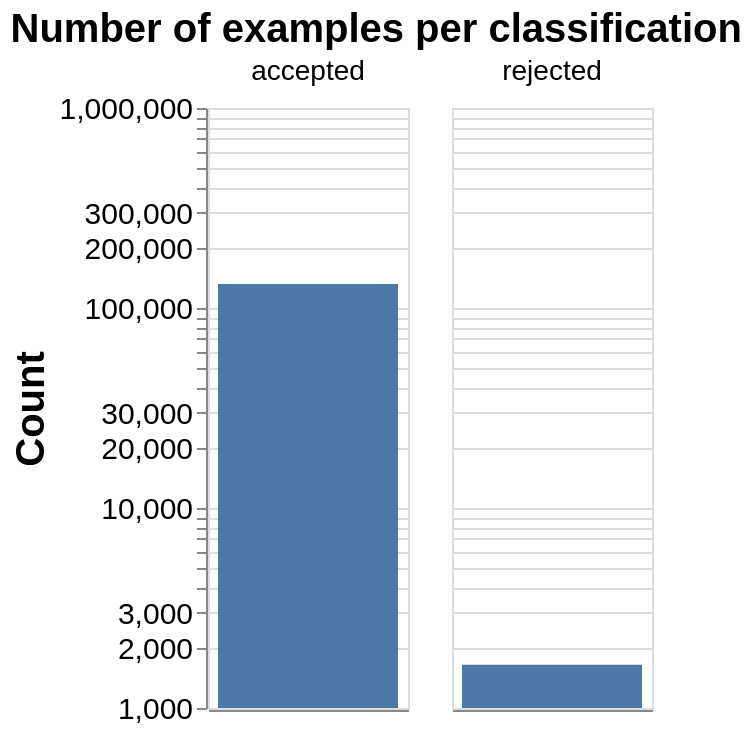

To address this issue, we undersampled the “accepted” observations to achieve more balanced counts per class. After evaluating precision and recall values for each class with different number of observations for the “accepted” class, we decided to randomly sample 2000 observations to create a reduced dataset to use to train our model. Though we understand that oversampling through bootstrapping, SMOTE or some other method is preferable, we determined that we had too few observations in the “rejected” class to effectively bolster the class near the observation count in the “accepted class”. Especially given that our dataset has only a single column, and we must engineer our features.

This leaves us with 3646 examples, 2000 for the accepted class, and 1646 for the rejected class. The dataset was separated into 64% train, 16% validation, and 20% test splits before any model or feature optimization took place.

## Feature Engineering

To engineer features, we used Sci-kit Learn’s `CountVectorizer` (Pedregosa et al. (2011)) transformer to split each `plate` string into character n-grams of a specified length range. For example, if an observed plate was `CATSROCK` and we were including n-grams of length 2-8, the features created would be `CA`, `AT`, `TS`, and so on for length 2; `CAT`, `ATS`, `TSR` and so on for length 3; `CATS`, `ATSR`, `TSRO` and so on for length 4 up to n-grams of length 8 for a total of 28 features. We decided in advance to evaluate n-grams with a minimum length of 2 since single letters or numbers are not relevant to our research question. The maximum number of characters on a plate is 8, so that is the maximum length of n-grams we evaluated. The total set of features engineered from our training set of 2332 observations is 25,889 n-grams varying in length from 2-8. It’s expected that any single length-2 features might occur more frequently than a longer-length feature, as a 2-character sequence can appear in multiple unique `plate` observations. It’s expected that each length-8 feature occurs only once, as there should not be any duplicate `plate` observations. This behavior is confirmed in the chart below where the distribution of frequency in the training data is plotted for a subset of feature lengths. We see a clear trend in decreased frequency of features with increasing feature length.

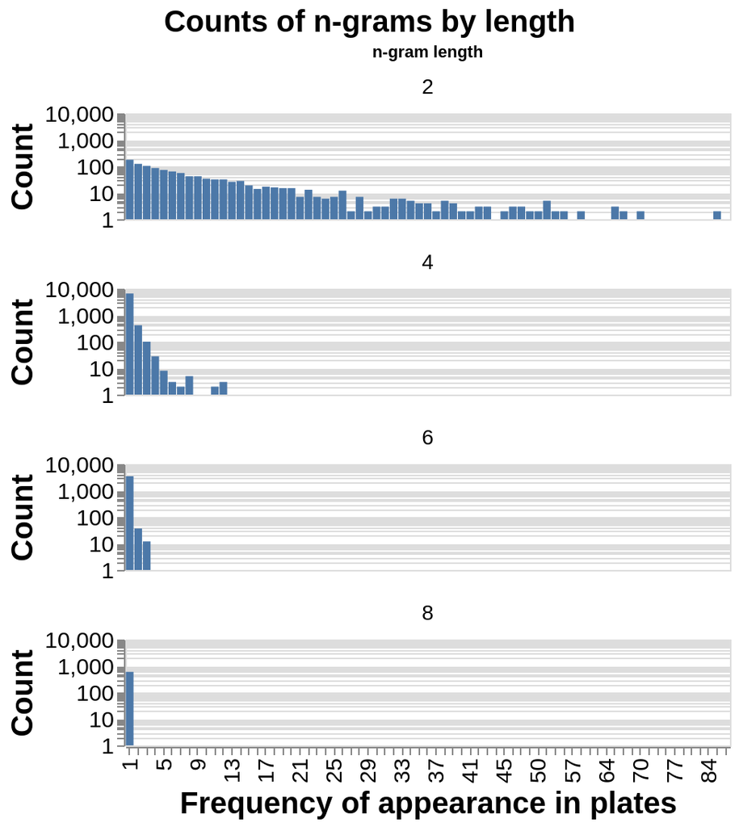

We can dig a bit deeper and examine the distribution of proportion per class for features of different lengths. 200 samples were drawn from the set of features of each n-gram length. For each feature in a sample, the proportion of times it appeared in each class was calculated. From the distribution of these proportions, displayed below, we see that n-grams of length 2 are most evenly distributed between classes. This indicates that an n-gram of length 2 is less likely to be a strong preditor. In comparison, for features of length 4-8, all features occur exclusively in one class. Therefore, we might expect a longer-length feature to be a better predictor.

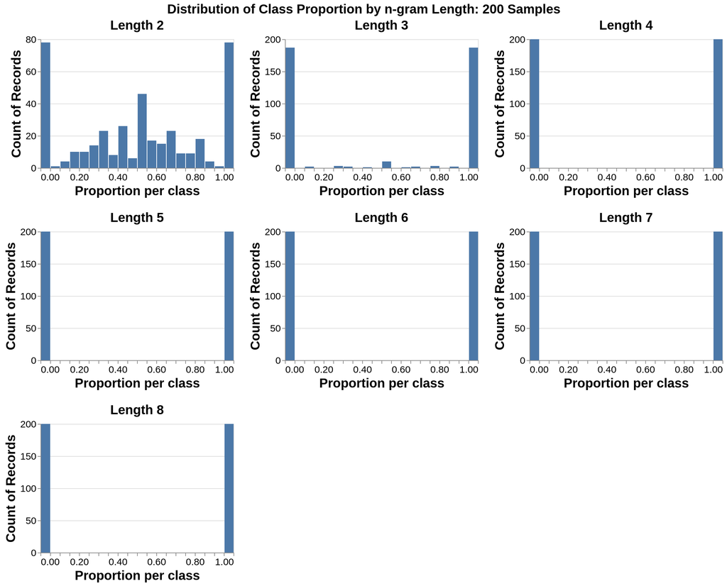

## Analysis

The multinomial Naive Bayes (`MultinomialNB` (Pedregosa et al. (2011)) ) algorithm was used to build a classification model to predict whether a license plate was ‘accepted’ or ‘rejected’ (found in the outcome column of the data set). We chose to fit a `MultinomialNB` model because the strength of predictors is easily interpretable, and the model performs efficiently on high-dimension datasets. Based on the exploratory data analysis it was deemed important to optimize the range of n-grams used in `CountVectorizer` (Pedregosa et al. (2011)) during feature engineering. We also needed to choose a proper `analyzer` to build the classification model. To this end, we used a model pipeline to optimize these hyperparameters using `GridSearchCV`. (Pedregosa et al. (2011)) The optimization results gave the best n-grams range of `(2,5)` and `char_wb` for `analyzer`.

*The **R** (R Core Team (2019)) and **Python** (Python Core Team (n.d.)) programming languages, and the following R and Python packages were used to perform this analysis: **Tidyverse** (Wickham (2017)) and **Dopcopt** (de Jonge (2018)) libraries and **Altair** (VanderPlas et al. (2018)), **Numpy** (Oliphant (n.d.)), **Pandas** (McKinney and others (2010)) and **Sci-kit Learn** (Pedregosa et al. (2011)). The code used to perform the analysis and create this report can be found in our [Github repository.](https://github.com/UBC-MDS/DSCI_522_group_415)*

# Results

The optmized model was fit using the training data that provided accuracy of 99.6%, while the test accuracy was 78.3%. The model seems to be overfitting but provides us good benchmark for further improvements. The model’s `precision` and `recall`, as shown below, indicate that the model performs pretty well when predicting both classes which confirms its practical functionality.

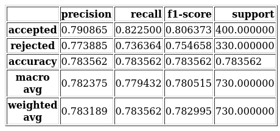

The strongest feature predictors for plate rejection and acceptance are given below. These predictors provide us some information regarding the combinations most prone to rejection.

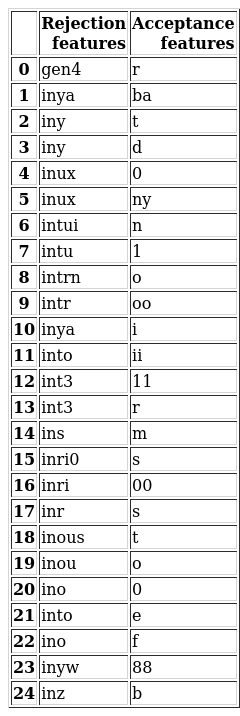

# Conclusions

The model evaluation metrics shown above indicate that you can, with decent accuracy, predict whether or not a vanity plate that “follows the rules” will be rejected by the NYSDMV. Furthermore, we identified the top 25 strongest predictors of rejection that the NYSDMV may consider adding to their re-guide to make their initial screening more effective, and ultimately, save the clerical staff significant time re-processing previously rejected applications.

We recognize room for imporovement in our analysis, including testing other classification models, better visualizing the features identified as “best predictors” of rejection, and performing feature selection. It’s clear that many of the features are highly correlated, (i.e. `inya`, `iny`), and some even repeated. Removing repeated and correlated features could result in a higher accuracy.

# References

“Datanews/Licence-Plates.” 2014. *Github*. https://github.com/datanews/license-plates.

de Jonge, Edwin. 2018. *Docopt: Command-Line Interface Specification Language*. https://CRAN.R-project.org/package=docopt.

“Learn About Personalized Plates.” 2019. *New York DMV*. https://dmv.ny.gov/learn-about-personalized-plates.

“Licence Plates: A Timeline.” 2015. *Historic Vehicle Association (HVA)*. https://www.historicvehicle.org/licence-plates-a-timeline/.

McKinney, Wes, and others. 2010. “Data Structures for Statistical Computing in Python.” In *Proceedings of the 9th Python in Science Conference*, 445:51–56. Austin, TX.

Oliphant, Travis. n.d. “NumPy: A Guide to NumPy.” USA: Trelgol Publishing. http://www.numpy.org/.

Pedregosa, F., G. Varoquaux, A. Gramfort, V. Michel, B. Thirion, O. Grisel, M. Blondel, et al. 2011. “Scikit-Learn: Machine Learning in Python.” *Journal of Machine Learning Research* 12: 2825–30.

Python Core Team. n.d. *Python: A Dynamic, Open Source Programming Language.* Python Software Foundation. https://www.python.org/.

R Core Team. 2019. *R: A Language and Environment for Statistical Computing*. Vienna, Austria: R Foundation for Statistical Computing. https://www.R-project.org/.

“Restrictions on Personalized Plates.” 2018. *New York DMV*. https://dmv.ny.gov/plates/restrictions-personalized-plates.

VanderPlas, Jacob, Brian Granger, Jeffrey Heer, Dominik Moritz, Kanit Wongsuphasawat, Arvind Satyanarayan, Eitan Lees, Ilia Timofeev, Ben Welsh, and Scott Sievert. 2018. “Altair: Interactive Statistical Visualizations for Python.” *Journal of Open Source Software*, December. The Open Journal. https://doi.org/10.21105/joss.01057.

Wickham, Hadley. 2017. *Tidyverse: Easily Install and Load the ’Tidyverse’*. https://CRAN.R-project.org/package=tidyverse.